# Napredne funkcionalnosti na Postgresql

## Napredne funkcionalnosti na bazah

- Priklop na Sqlite in Postgres preko Pythona in R
- Namestitev Linuxa, Postgresql
- Uporabniki, vloge ter dostop
- Indeksi
- Transakcije
- Določanje dostopa
- Shranjene funkcije
- Prožilci (Triggerji)
- Pogledi (View)
- Ogledali si bomo na RDBMS PostgreSQL

## Sqlite in Postgres preko Pythona in R

- Ogledali si bomo konkretne primere (mapica `viri`).
- Za Postgres potrebujemo bazo, kjer imamo dovolj pravic.

## Namestitev Linuxa

- Virtualizacija: zaganjanje drugega operacijskega sistema (celotnega računalnika) kot programa.
- Virtualbox - program za virtualizacijo (Oracle).
- Iz spleta naložimo program [Virtualbox](https://www.virtualbox.org/).
- Iz spleta naložimo .iso sliko za namestitev operacijskega sistema [Linux Ubuntu Server](https://www.ubuntu.com/download/server).
- Po [navodilih](https://www.virtualzero.net/blog/how-to-install-ubuntu-server-18.04-lts-in-virtualbox) nastavimo virtualni računalnik in namestimo Linux.
- POZOR: za uporabnika nastavimo uporabniško ime `ubuntu` in dogovorjeno geslo.

## Osnovno delo v terminalu

- Namestili smo `Ubuntu Server`, ki omogoča samo terminalski dostop.
- Lahko bi si namestili `Ubuntu Desktop`, ki ponuja tudi uporabo preko ukazne lupine.
- V terminal se po zagonu prijavimo kot uporabnik `ubuntu`.
- Uporabnik `ubuntu` je član skupine `sudoers` in lahko preko ukaza `sudo` izvaja operacije s pravicami administratorja.
- Spoznamo se z nekaj [osnovnimi ukazi](https://help.ubuntu.com/community/Beginners/BashScripting#Commands) v ukazni lupini `bash`.

## Pomembni ukazi v `bash`

- `pwd` - v kateri mapi se nahajamo
- `ls` - izpis vsebine mape (`ls -l`, `ls -lt`)
- `cd` - spremeni mapo (`cd podmapa`, `cd ..`, `cd /home/ubuntu`, `cd`, …)
- `cp` - kopiranje (`cp datoteka1 datoteka2`, `cp -r pot/do/mape pot/do/cilja`)
- `mv` - premikanje oz. preimenovanje (`mv datoteka1 datoteka2`, `mv mapa1 pot/do/mape2`)
- `rm` - briši (`rm datoteka`, `rm -r mapa`)
- `nano` - preprost tekstovni urejevalnik (`nano pot/do/datoteke.txt`)
- `sudo` - izvajanje ukazov z administratorskimi pravicami

## [Namestitev Postgresql](https://www.digitalocean.com/community/tutorials/how-to-install-and-use-postgresql-on-ubuntu-14-04)

- Nameščanje na Ubuntu izvajamo preko paketnega sistema in ukaza `apt-get`.

```bash
sudo apt-get update
sudo apt-get install postgresql postgresql-contrib
```

- Ob namestitvi se na sistemu ustvari uporabnik `postgres`, ki je tudi administrator na bazi.
- Vstop v vlogo (uporabnika) `postgres`:

```bash
sudo -i -u postgres
```

## Program `pqsl`

- Program za priklop na bazo - `psql`. Priklop na bazo kot uporabnik `postgres`.

```bash
psql
```

- Poln ukaz za priklop (glej tudi `man psql`).

```bash
psql -h baza.fmf.uni-lj.si -U student banka
```

- `\q` - izhod
- `\h` - pomoč glede ukazov v SQL
- `\conninfo` - parametri priklopa na bazo
- `\du` - pregled vlog na bazi
- `\d` - pregled tabel
- `\?` - pomoč z izpisom vsah ukazov v `psql`

## Uporabniki na bazi

- Na bazo se priklopimo z zadostnimi pravicami.
- Npr. na Linuxu pod uporabniškim imenom `postgres` zaženemo klienta `psql`.
- Ustvarjanje uporabnika

```sql
CREATE USER uporabnisko_ime WITH ENCRYPTED PASSWORD '********';
```

- Postgres pozna uporabnike in skupine, ampak jih enovito uporablja preko posplošitve (vloge) - `ROLE`.
- Uporabnika definiramo lahko tudi takole:

```sql
CREATE ROLE ime_vloge WITH LOGIN;
```

- Vlogam dodeljujemo pravice, vlogo lahko obravnavamo kot uporabnika (če ima pravico `WITH LOGIN`) ali kot skupino.

## Vloge

- Ustvarjanje vloge:

```sql
CREATE ROLE ime_vloge;
```

- Brisanje vloge:

```sql
DROP ROLE ime_vloge;
```

- Brisanje neobstoječe vloge vrne napako. Lahko uporabnimo tole:

```sql
DROP ROLE IF EXISTS ime_vloge;
```

## [Določanje pravic na vloge](https://www.digitalocean.com/community/tutorials/how-to-use-roles-and-manage-grant-permissions-in-postgresql-on-a-vps--2)

- Ustvarjanje vloge z dodelitvijo pravice prijave:

```sql
CREATE ROLE demo_role WITH LOGIN;
```

- Popravek pravice prijave:

```sql
ALTER ROLE ime_vloge WITH NOLOGIN;
```

## Ustvarjanje podatkovnih baz

- Na bazo moramo biti priklopljeni kot uporabnik z dovolj pravicami (npr. administrator `postgres`)

```sql
CREATE DATABASE ime_baze;
```

- Ustvarimo novo bazo, se priklopimo nanjo in preverimo priklop.

```sql
CREATE DATABASE nova;
\c nova
\conninfo
```

- Ustvarimo novo tabelo in nekaj vnosov.

```sql
CREATE TABLE oseba (emso TEXT PRIMARY KEY, ime TEXT, priimek TEXT);
INSERT INTO oseba (emso, ime, priimek) VALUES ('1234', 'Janez', 'Novak');
```

## [Dodelitev pravic na vloge](https://www.digitalocean.com/community/tutorials/how-to-use-roles-and-manage-grant-permissions-in-postgresql-on-a-vps--2)

- Splošen ukaz za dodelitev pravice.

```sql
GRANT tip_pravice ON tabela TO ime_vloge;
```

- Dodelitev pravice popravljanja na tabeli uporabniku.

```sql
GRANT UPDATE ON tabela TO uporabnik;
```

- Dodelitev vseh pravic na tabeli uporabniku.

```sql
GRANT ALL ON tabela TO uporabnik;
```

## [Odvzemanje pravic vlogam](https://www.digitalocean.com/community/tutorials/how-to-use-roles-and-manage-grant-permissions-in-postgresql-on-a-vps--2)

- Onemogočanje pravic.

```sql
REVOKE tip_pravice ON tabela FROM ime_vloge;
```

- Primer: onemogočanje vstavljanja vsem skupinam.

```sql
REVOKE INSERT ON tabela FROM PUBLIC;
```

## Sheme

- Uporabniki in vloge so vidne preko celotnega Postgres RDBMS.
- S `psql` ali kakim drugim klientom (npr. pgAdmin 4) se lahko priklopimo na točno določeno bazo.
- Sheme so imenski prostori znotraj ene podatkovne baze, v katerih živijo tabele in drugi logični objekti (npr. števci, shranjene funkcije).
- Uporabljamo jih za lažje določanje pravic na tabelah, boljšo logično organizacijo objektov in razreševanje imenskih konfliktov.
- Ko ustvarimo neko podatkovno bazo, se ustvari tudi shema `public` v kateri so nove tabele.
- Na tabele na podatkovni bazi se sklicujemo v obliki `ime_sheme.ime_tabele`.

## Primer

- Ustvarimo uporabnika `janez`.

```sql
CREATE USER janez WITH ENCRYPTED PASSWORD 'pomlad';
```

- Poglejmo obstoječe uporabnike.

```sql
\du
```

- Odjavimo se in poskusimo priklopiti na bazo.

```bash
psql -h localhost -U janez nova
```

- Poizvedba ni možna:

```sql
select * from oseba;
```

## Primer

- Odjavimo se in prijavimo kot uporabnik `postgres`.

```bash
psql
```

- Izvedemo naslednje:

```sql
\c nova
REVOKE ALL ON DATABASE nova FROM PUBLIC;
GRANT CONNECT ON DATABASE nova TO janez;
GRANT USAGE ON SCHEMA public TO janez;
GRANT ALL ON ALL TABLES IN SCHEMA public TO janez;
GRANT ALL ON ALL SEQUENCES IN SCHEMA public TO janez;
```

- preverimo pravice na bazi, shemi in tabelah na bazi.

```sql
\l
\dn+
\dp
```

## Vloge kot skupine

- Ustvarjanje skupine in dodajanje uporabnikov.

```sql
CREATE ROLE skupina;
GRANT skupina TO uporabnik1;
GRANT skupina TO uporabnik2;
```

- V resnici dajamo lahko “vloge na vloge” - tako kot bi dajali skupine v skupine, uporabnike pa si predstavljamo kot elementarne skupine s pravico priklopa.
- Uporabnik v neki skupini se začne obnašati skladno z vlogo, če to vklopimo:

```sql
SET ROLE skupina;
```

## Skupine

- V osnovno vlogo se vrnemo:

```sql
RESET ROLE;
```

- Lahko pa uporabniku posebej nastavimo, da avtomatično podeduje pravice iz skupin/vlog.

```sql
ALTER ROLE uporabnik INHERIT;
```

- To pomeni: če uporabniku nastavimo lastnost `INHERIT`, mu ni treba vsakič “skakati” v vloge s pomočjo `SET ROLE` ampak se pravice iz vseh vlog, v katerih “je”, avtomatično upoštevajo.

## Primer - dovoljevanje dostopa preko skupine

- Odjavimo se in prijavimo kot uporabnik `postgres`.

```bash
psql
```

- Izvedemo naslednje:

```sql
\c nova
CREATE ROLE novaadmini;
REVOKE ALL ON DATABASE nova FROM PUBLIC;
GRANT CONNECT ON DATABASE nova TO noviadmini;
GRANT USAGE ON SCHEMA public TO noviadmini;
GRANT ALL ON ALL TABLES IN SCHEMA public TO noviadmini;
GRANT ALL ON ALL SEQUENCES IN SCHEMA public TO noviadmini;
\l
\dn+
\dp
```

## Primer - dovoljevanje dostopa preko skupine

- Uporabniku dodelimo pravico.

```sql
CREATE USER metka WITH ENCRYPTED PASSWORD 'pomlad';
ALTER ROLE metka INHERIT;
GRANT noviadmini TO metka;
\du
```

- Če želimo ohranjanje privzetih pravic na novih objektih

```sql
ALTER DEFAULT PRIVILEGES FOR ROLE metka IN SCHEMA public
GRANT ALL ON TABLES TO noviadmini;
ALTER DEFAULT PRIVILEGES FOR ROLE metka IN SCHEMA public
GRANT ALL ON SEQUENCES TO noviadmini;
```

## Lažji oddaljen priklop na bazo

- Tipično imamo podatkovno bazo na nekem strežniku.
- Lahko se sicer priklopimo nanjo preko programa `psql` (ukazna vrstica).
- Tipkanje v terminalu `psql` je velikokrat nepriročno.
- Najbolj priročno je do baze dostopati preko ustreznih aplikacij z grafičnim vmesnikom.
- Primer take aplikacije: phpPgAdmin (https://baza.fmf.uni-lj.si), ki se uporablja na vajah.

## Konfiguracija strežnika za oddaljen dostop

- Najprej popravimo datoteko `postgresql.conf`.
- Lokacijo najdemo z ukazom

```bash
psql -U postgres -c 'SHOW config_file'
```

- S pomočjo urejevalnika `nano` popravimo ustrezno vrstico na:

```bash
listen_addresses = '*'
```

- Urejevalnik zaženemo npr. kot

```bash
nano /etc/postgresql/12/main/postgresql.conf
```

## Oddaljen dostop - konfiguracija

- Lokacijo konfiguracijske datoteke `pg_hba.conf` najdemo z ukazom

```bash
psql -U postgres -c 'SHOW hba_file'
```

- S pomočjo urejevalnika `nano` popravimo vrstico oblike

```bash
host      all      all      127.0.0.1/32     md5
```

v vrstico

```bash
host      all      all      0.0.0.0/0     md5
```

- Urejevalnik zaženemo npr. kot

```bash
nano /etc/postgresql/12/main/pg_hba.conf
```

## Oddaljen dostop - konfiguracija

- Da uveljavimo nove nastavitve, ponovno zaženemo strežnik (kot uporabnik `ubuntu`)

```bash
service postgresql restart
```

- Za ustavljanje in zagon RDBMS PostgreSql lahko uporabimo podoben ukaz (namesto parametra `restart` lahko uporabimo parametra `stop` oz. `start`).

## PgAdmin 4

- Namizna alternativa: program `PgAdmin 4` (namestimo iz: https://www.pgadmin.org/download/).
- V programu konfiguriramo povezavo podobno kot v `psql`.
- Namesto ukazov v `psql` oblike `\ukaz` imamo grafične preglede in ukaze preko menijev.
- Poizvedbe izvajamo preko orodja `Query tool`.

## Priklop preko PgAdmin 4

- Virtualni strežnik mora imeti mrežni vmesnik nastavljen na `Bridged Adapter`, t.j. mora biti na isti mreži, kot je naš računalnik.
- Za priklop rabimo naslov strežnika (`host`), uporabnika (`user`), njegovo geslo in ime podatkovne baze, na katero se priklapljamo.
- IP številko virtualnega računalnika dobimo z ukazom v terminalu:

```bash
ip address
```

- Predno omogočimo uporabniku `postgres` (t.j. administratorju) oddaljen priklop, mu moramo nastaviti geslo

```bash
psql
\password
```

Dvakrat vnesemo novo geslo. - V nadaljevanju bomo komunicirali s podatkovno bazo preko PgAdmin 4.

## Indeksi

- Iskanje po splošnem stolpcu v podatkovni bazi zahteva \(O(n)\) časa.
- Če je podatkovni tip stolpca linearno urejena množice lahko nad vrsticami stolpca izgradimo iskalno strukturo, ki omogoča iskanje v \(O(1)\) ali \(O(\log n)\).
- Strukturo imenujemo `index`.

## Indeksi - primer

- Ustvarimo tabelo.

```sql
CREATE TABLE tabela (
    id INTEGER,
    vsebina varchar
);
```

- Na stolpcu `id` ustvarimo indeks.

```sql
CREATE INDEX index1 ON tabela (id);
```

- Poglejmo, kakšne indekse imamo.

```sql
\di
```

## Indeksi

- Vzdrževanje indeksov zahteva določeno dodatno delo (ob vsakem popravku baze).
- Odstranjevanje indeksa:

```sql
DROP INDEX index1;
```

- Tipi indeksov:
  - B-tree: linearno urejene množice
  - Hash: zgoščena tabela. Možno samo iskanje po enakosti.
  - GiST, SPGiST, GIN, …
- Primer:

```sql
CREATE INDEX name ON table USING hash (column);
```

## Indeksi

- Indekse se lahko naredi za več stolpcev.

```sql
CREATE INDEX index_name
ON table_name (column1_name, column2_name);
```

- Primarni in sekundarni ključi so že indeksirani.
- Indeksi na izrazih nad stolpci:

```sql
CREATE INDEX users_lower_email ON users(lower(email));
```

- Tak indeks omogoča hitro iskanje po pogojih oblike `WHERE lower(email) = ??`

## Transakcije

- Lastnosti transakcij - ACID:
  - Atomarnost: vse operacije v transakciji izvedene ali zavernjene
  - Konsistentnost: pred in po transakciji je stanje v bazi konstentno
  - Izolacija: transakcije so izolirane med seboj in medsebojni vpogled je pregleden.
  - Trajnostnost: rezultat transakcije je trajno shranjen.
- Ukazi:
  - `BEGIN` ali `BEGIN TRANSACTION` - začetek transakcije
  - `COMMIT` ali `END TRANSACTION` - konec transakcije, shrani spremembe
  - `ROLLBACK` - razveljavi spremembe

## Primer

```sql
\c nova
CREATE TABLE blagajna (ime TEXT, znesek NUMERIC(10,2));
INSERT INTO blagajna (ime, znesek) VALUES ('Janez', 10), ('Metka', 10);
BEGIN;
  UPDATE blagajna SET
    znesek=(SELECT znesek FROM blagajna WHERE ime='Janez') - 5
  WHERE ime='Janez';
  UPDATE blagajna SET
    znesek=(SELECT znesek FROM blagajna WHERE ime='Metka') + 5
  WHERE ime='Metka';
COMMIT;
```

## Nivo izolacije

- Problemi:
  - `umazano branje` - preberemo “nekomitane” podatke
  - `neponovljivo branje` - v transakciji večkrat beremo iste podatke, a se je nek podatek vmes spremenil.
  - `fantomsko branje` - v transakciji večkrat naredimo isto poizvedbo in zaradi spremembe podatkov dobimo več ali manj vrstic
- Nivoji izolacije:

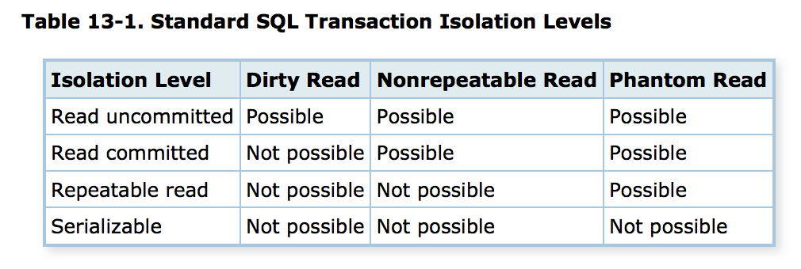

## Nivo izolacije

- Privzeti nivo je READ COMMITED.
- Lahko ga nastavimo:

```sql
SET TRANSACTION SERIALIZABLE | REPEATABLE READ |
        READ COMMITTED | READ UNCOMMITTED
```

## Shranjene funkcije

- Na RDBMS lahko napišemo posebne funkcije v različnih programskih jezikih.
- Prednosti:
  - Zmanjšanje komunikacije z podatkovno bazo
  - Izboljšanje učinkovitosti
  - Souporaba v večih bazah
- Slabosti:
  - Počasnejši in težji razvoj programske opreme
  - Težko razhroščevanje, vodenje verzij
  - Težja prenosljivost med različnim RDBMS
- Razen v posebnih primerih se v veliki večini primerov danes izogibamo uporabe shranjenih funkcij.

## [Definicija funkcij](http://www.postgresqltutorial.com/postgresql-create-function/)

- Sintaksa:

```sql
CREATE FUNCTION function_name(p1 type, p2 type)
 RETURNS INTEGER AS
BEGIN
 -- koda ...
END;
LANGUAGE language_name;
```

## Definicija funkcij - primer

```sql
CREATE FUNCTION povecaj(n INTEGER) RETURNS INTEGER AS
$$
BEGIN
  RETURN n + 1;
END;
$$
LANGUAGE plpgsql;
```

- Uporaba

```sql
SELECT povecaj(20)
```

## Prožilci

- ang `TRIGGER` - posebna funkcija, ki je povezana s tabelo.
- Sproži se ob dogodkih povezanih z operacijami: `INSERT`, `UPDATE`, `DELETE`.
- Lahko se proži za vsak stavek posebej ali za vsako vrstico posebej.
- Lahko se proži pred ali po dogodku.

## [Prožilci - primer](http://www.postgresqltutorial.com/creating-first-trigger-postgresql/)

- Ustvarimo tabelo zaposlenih:

```sql
CREATE SEQUENCE "stevec_zaposlenih" START 1;
CREATE TABLE zaposleni (
   id INTEGER DEFAULT nextval('stevec_zaposlenih') NOT NULL,
   ime varchar(40) NOT NULL,
   priimek varchar(40) NOT NULL
);
```

## [Prožilci - primer](http://www.postgresqltutorial.com/creating-first-trigger-postgresql/)

- Ustvarimo tabelo sprememb:

```sql
CREATE SEQUENCE "stevec_zaposleni_spremembe" START 1;
CREATE TABLE zaposleni_spremembe (
   id INTEGER DEFAULT nextval('stevec_zaposleni_spremembe') NOT NULL,
   zaposleni_id INTEGER NOT NULL,
   priimek varchar(40) NOT NULL,
   spremenjeno TIMESTAMP(6) NOT NULL
);
```

## Prožilci - primer

- Prožilna funkcija:

```sql
CREATE OR REPLACE FUNCTION belezi_spremembe()
  RETURNS trigger AS
$BODY$
BEGIN
  IF NEW.priimek <> OLD.priimek THEN
     INSERT INTO zaposleni_spremembe(zaposleni_id,priimek,spremenjeno)
         VALUES(OLD.id,OLD.priimek,now());
    END IF;
    RETURN NEW;
END;
$BODY$ LANGUAGE plpgsql;
```

## Prožilci - primer

- Povezava funkcije s prožilcem:

```sql
CREATE TRIGGER zadnje_spremembe
  BEFORE UPDATE
  ON zaposleni
  FOR EACH ROW
  EXECUTE PROCEDURE belezi_spremembe();
```

```sql
INSERT INTO zaposleni (ime, priimek) VALUES ('Janez', 'Novak');
INSERT INTO zaposleni (ime, priimek) VALUES ('Metka', 'Lepše');
SELECT * FROM zaposleni;
UPDATE zaposleni SET priimek = 'Zelenko' WHERE ID = 2;
SELECT * FROM zaposleni;
SELECT * FROM zaposleni_spremembe;
```

## [Pogledi (`VIEW`)](http://www.tutorialspoint.com/postgresql/postgresql_views.htm)

- Virtualne tabele kot rezultat poizvedbe, s katerimi lahko delamo tako, kot s pravimi tabelami (poizvedbe, pravice).
- Pogled lahko predstavlja tabelo, ki določenim uporabnikom bolje predstavi podatke, ki jih pogosto povzamemo iz večih tabel (npr. seštevki transakcij po računih).
- Uporabnikom lahko dodelimo pravice samo na (izbrane) poglede.
- Pogledi so definirani kot (shranjene) poizvedbe.

## [Pogledi (`VIEW`)](http://www.tutorialspoint.com/postgresql/postgresql_views.htm)

- Ustvarjanje pogleda:

```sql
CREATE VIEW ime_pogleda AS poizvedba;
```

- `poizvedba` - stavek `SELECT`
- Brisanje pogleda:

```sql
DROP VIEW ime_pogleda;
```

## Pogledi - primer

```sql
CREATE VIEW samo_priimki_zaposlenih AS SELECT id, priimek FROM zaposleni;
SELECT * FROM samo_priimki_zaposlenih
```